# Project 1 - KNN, KKNN, logistic regression, ROC, AUC

Julia Pawlus

Task 1. Preliminary Questions

For what purpose is a dataset divided into a training set and a test set? How should this division be carried out?

The division is used in conducting machine learning methods, where training sets are utilized for estimating parameters and comparing performance, while test data is used to compare and verify whether the model works correctly and is properly constructed. Most commonly, the training part of the model constitutes 80% of the data, and the test part makes up the remaining 20%.

What is a confusion matrix?

A confusion matrix helps to easily present the assumptions regarding our project by indicating which factors occur through positive classification (correctly classified), negative classification (incorrectly classified), as well as false positives (incorrect classification, Type I error) and false negatives (incorrect classification, Type II error).

What is the difference between accuracy, sensitivity, and specificity? Which of these measures is more important and in what case? Provide examples.

Accuracy is the percentage of correct classifications achieved by the trained model among all cases. Sensitivity is a measure that considers all cases where the true value is Y=1. Specificity is a measure that considers all cases where the true value is Y=0. Referring to the given dataset from the “stroke” file, sensitivity would be the most important measure for us because we aim for the highest possible number of true cases where Y=1—in our case, as many instances of strokes as possible.

```r
library(readr)
library(tidyverse)
library(ROSE)
```

```r
library(ggplot2)
library(pROC)
library(caret)
library(class)
library(ggplot2)
library(kknn)
data <- read.csv("stroke.csv", sep = ";")
data <- head(data, 3500)

KCount<-30
```

```r
data$gender <- as.factor(data$gender)
data$age <- as.numeric(data$age)
data$hypertension <- as.factor(data$hypertension)
data$heart_disease <- as.factor(data$heart_disease)
data$ever_married <- as.factor(data$ever_married)
data$work_type <- as.factor(data$work_type)
data$Residence_type <- as.factor(data$Residence_type)
data$avg_glucose_level <- as.numeric(data$avg_glucose_level)
data$bmi <- as.numeric(data$bmi)
data$smoking_status <- as.factor(data$smoking_status)
data$stroke <- as.factor(data$stroke)
```

```r
data %>%
   select_if(is.factor) %>%
  summary()
```

```
##     gender     hypertension heart_disease ever_married         work_type
##  Female:2032   0:3132       0:3287        No :1160     children     : 441
##  Male  :1468   1: 368       1: 213        Yes:2340     Govt_job     : 435
##                                                        Never_worked :  15
##                                                        Private      :2042
##                                                        Self-employed: 567
##  Residence_type         smoking_status stroke
##  Rural:1734     formerly smoked: 626   0:3251
##  Urban:1766     never smoked   :1282   1: 249
##                 smokes         : 554
##                 Unknown        :1038
##
```

```r
data %>%
  select_if(is.numeric) %>%
  summary()
```

```
##       age        avg_glucose_level      bmi
##  Min.   : 0.08   Min.   : 55.22    Min.   :10.30
##  1st Qu.:26.00   1st Qu.: 77.58    1st Qu.:23.60
##  Median :46.00   Median : 92.28    Median :28.20
##  Mean   :44.28   Mean   :107.26    Mean   :29.01
##  3rd Qu.:62.00   3rd Qu.:114.88    3rd Qu.:33.10
##  Max.   :82.00   Max.   :271.74    Max.   :97.60
##                                    NA's   :159
```

```r
data <- data %>%
  group_by(gender) %>%
  mutate(bmi = ifelse(is.na(bmi), mean(bmi, na.rm = TRUE), bmi)) %>%
  ungroup()
```

```r
data %>%
  select(bmi) %>%
  summary()
```

```
##       bmi
##  Min.   :10.30
##  1st Qu.:23.90
##  Median :28.50
##  Mean   :29.01
##  3rd Qu.:32.80
##  Max.   :97.60
```

```r
set.seed(1234)
```

#Split into Training and Test Set

```r
sample_set <- sample(nrow(data), round(nrow(data)*.80), replace = FALSE)
```

```r
data_train <- data[sample_set, ]
```

```r
data_test <- data[-sample_set, ]
```

#Proportions of Classes in the Entire, Training, and Test Sets

```r
round(prop.table(table(select(data, stroke), exclude = NULL)), 4)* 100
```

```
## stroke
##     0     1
## 92.89  7.11
```

```r
round(prop.table(table(select(data_train, stroke), exclude = NULL)), 4)* 100
```

```
## stroke
##     0     1
## 92.86  7.14
```

```r
round(prop.table(table(select(data_test, stroke), exclude = NULL)), 4)* 100
```

```
## stroke
##  0  1
## 93  7
```

#Balancing the Training Set Using ROSE

```r
table(data_train$stroke)
```

```
##
##    0    1
## 2600  200
```

```r
data_train <- ROSE(stroke~.,data=data_train, p=0.5, N=round(nrow(data)*.80), seed = 1 )$data
table(data_train$stroke)
```

```
##
##    0    1
## 1463 1337
```

```r
round(prop.table(table(select(data_train, stroke), exclude = NULL)), 4)* 100
```

```
## stroke
##     0     1
## 52.25 47.75
```

Task 2. KNN Method

How does the k-nearest neighbors (KNN) method work?

The k-nearest neighbors method determines the nearest neighbors for each element based on the assumption that close elements are similar. It takes into account the distance from the new element relative to its neighbors.

What is ‘k’ in the KNN method? How to choose the appropriate value of ‘k’?

‘k’ is the number of nearest neighbors considered when classifying a new point. The appropriate value of ‘k’ is selected empirically, usually by testing different values and choosing the one that gives the best results on a validation set.

```r
normalize <- function(x){
  return((x - min(x))/ (max(x) - min(x)))
}
```

```r
data_train_k <- data_train %>%
  mutate(age = normalize(age),
         avg_glucose_level = normalize(avg_glucose_level),
         bmi = normalize(bmi)) %>%
  select(age, avg_glucose_level, bmi, stroke)

data_test_k <- data_test %>%
  mutate(age = normalize(age),
         avg_glucose_level = normalize(avg_glucose_level),
         bmi = normalize(bmi)) %>%
  select(age, avg_glucose_level, bmi, stroke)
```

```r
summary(data_train_k)
```

```
##       age         avg_glucose_level      bmi         stroke
##  Min.   :0.0000   Min.   :0.0000    Min.   :0.0000   0:1463
##  1st Qu.:0.5029   1st Qu.:0.2808    1st Qu.:0.3010   1:1337
##  Median :0.6628   Median :0.3508    Median :0.3646
##  Mean   :0.6289   Mean   :0.4032    Mean   :0.3725
##  3rd Qu.:0.7901   3rd Qu.:0.4902    3rd Qu.:0.4329
##  Max.   :1.0000   Max.   :1.0000    Max.   :1.0000
```

```r
summary(data_test_k)
```

```
##       age         avg_glucose_level      bmi         stroke
##  Min.   :0.0000   Min.   :0.0000    Min.   :0.0000   0:651
##  1st Qu.:0.2920   1st Qu.:0.1041    1st Qu.:0.1844   1: 49
##  Median :0.5728   Median :0.1641    Median :0.2564
##  Mean   :0.5357   Mean   :0.2401    Mean   :0.2655
##  3rd Qu.:0.7559   3rd Qu.:0.2780    3rd Qu.:0.3208
##  Max.   :1.0000   Max.   :1.0000    Max.   :1.0000
```

```r
# Function for prediction and calculating accuracy
data_train_labels <- data_train_k$stroke
data_test_labels <- data_test_k$stroke

prediction <- function(K) {
  knn_pred <- knn(train = data_train_k %>% select(-stroke),
                  test = data_test_k %>% select(-stroke),
                  cl = data_train_labels, k = K)

  accuracy <- sum(knn_pred == data_test_labels) / length(data_test_labels)

  return(accuracy)
}

# Testing different values of k
best_result <- -Inf
best_K <- 0
results_df <- data.frame(K = numeric(0), Result = numeric(0))

for (K in 1:KCount) {
  result <- prediction(K)
  cat("K =", K, "Accuracy =", result, "\n")
  results_df <- rbind(results_df, data.frame(K = K, Result = result))
  if (result > best_result) {
    best_result <- result
    best_K <- K
  }
}
```

```
## K = 1 Accuracy = 0.5614286
## K = 2 Accuracy = 0.5671429
## K = 3 Accuracy = 0.58
## K = 4 Accuracy = 0.5914286
## K = 5 Accuracy = 0.5885714
## K = 6 Accuracy = 0.5871429
## K = 7 Accuracy = 0.5728571
## K = 8 Accuracy = 0.58
## K = 9 Accuracy = 0.5757143
## K = 10 Accuracy = 0.5785714
## K = 11 Accuracy = 0.5671429
## K = 12 Accuracy = 0.5728571
## K = 13 Accuracy = 0.5842857
## K = 14 Accuracy = 0.5828571
## K = 15 Accuracy = 0.58
## K = 16 Accuracy = 0.5928571
## K = 17 Accuracy = 0.5871429
## K = 18 Accuracy = 0.5957143
## K = 19 Accuracy = 0.59
## K = 20 Accuracy = 0.59
## K = 21 Accuracy = 0.5942857
## K = 22 Accuracy = 0.59
## K = 23 Accuracy = 0.5885714
## K = 24 Accuracy = 0.59
## K = 25 Accuracy = 0.59
## K = 26 Accuracy = 0.5842857
## K = 27 Accuracy = 0.5885714
## K = 28 Accuracy = 0.5842857
## K = 29 Accuracy = 0.59
## K = 30 Accuracy = 0.5914286
```

```r
cat("Best result:", best_result, "for K =", best_K)
```

```
## Best result: 0.5957143 for K = 18
```

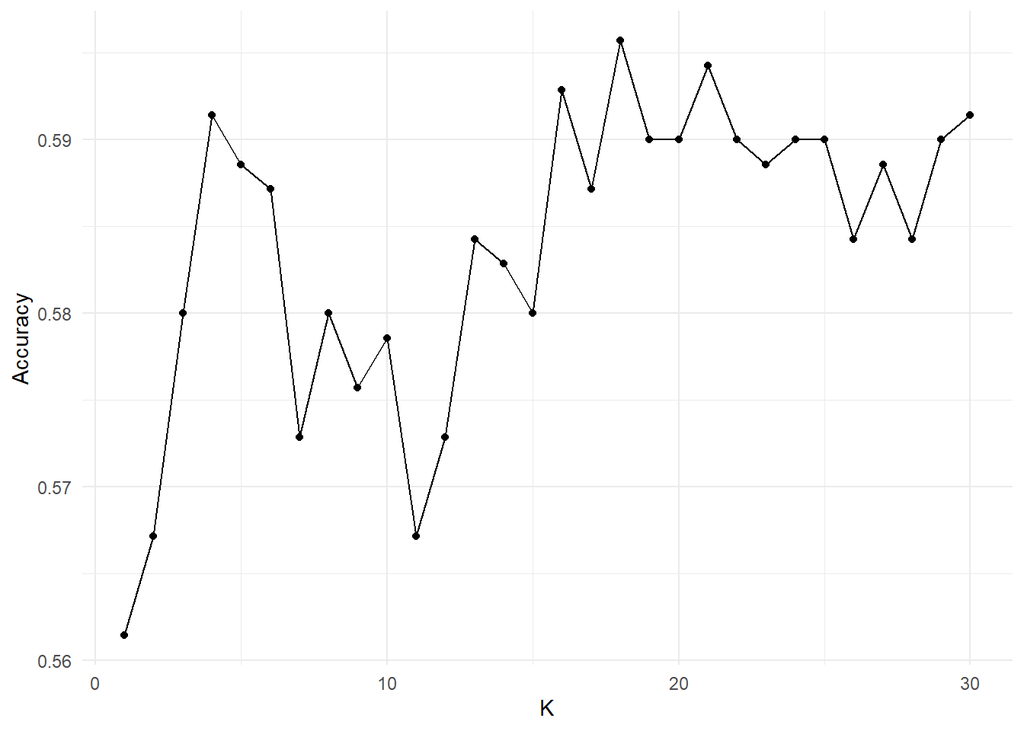

```r
# Plot of accuracy depending on k
ggplot(data = results_df, aes(x = K, y = Result)) +
  geom_line() +
  geom_point() +
  labs(x = "K", y = "Accuracy") +
  theme_minimal()
```

5. How can the KNN method be used to solve a regression problem?

The KNN method can be applied to regression problems by calculating a numerical prediction for a new data point based on the average or weighted average of the numerical values of its K nearest neighbors. In KNN regression, we compute the distances between the target point and the training data, select the K closest neighbors, and then calculate the predicted value as the mean numerical value of these neighbors.

6. Does the size of the dataset matter in the case of this method? Check whether the number of observations affects the obtained results.

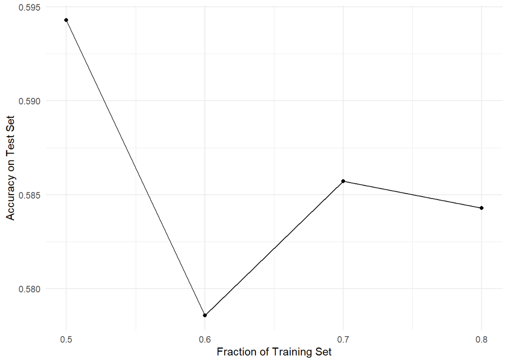

```r
# Testing the impact of the number of observations on results
fractions <- c(0.5, 0.6, 0.7, 0.8)
results_df <- data.frame(Fraction = numeric(0), Accuracy = numeric(0))

for (frac in fractions) {
  set.seed(123)
  sample_indices <- sample(1:nrow(data_train_k), size = floor(frac * nrow(data_train_k)))
  data_train_frac <- data_train_k[sample_indices, ]
  data_train_labels_frac <- data_train_frac$stroke

  knn_pred_frac <- knn(train = data_train_frac %>% select(-stroke),
                       test = data_test_k %>% select(-stroke),
                       cl = data_train_labels_frac, k = best_K)

  accuracy_frac <- sum(knn_pred_frac == data_test_labels) / length(data_test_labels)

  results_df <- rbind(results_df, data.frame(Fraction = frac, Accuracy = accuracy_frac))
}

# Plot
ggplot(data = results_df, aes(x = Fraction, y = Accuracy)) +
  geom_line() +
  geom_point() +
  labs(x = "Fraction of Training Set", y = "Accuracy on Test Set") +
  theme_minimal()
```

Task 2. KNN Method

Can categorical variables be used in this method, and if so, how?

Yes, categorical variables can be used by encoding them into numerical values, for example, using dummy variables (one-hot encoding).

What are the advantages and disadvantages of this method?

Advantages of the KNN method:

It is easy to understand and implement. It does not make any assumptions about the distribution of the data used, which allows it to be applied to various problems. It can be used for both classification and regression problems. It is efficient because it works well with a large number of classes. The training phase is quick, mainly because this method does not construct a new model but uses available examples to make predictions when necessary. Disadvantages of the KNN method:

Difficulty in choosing the appropriate value of k. It does not work well with large datasets because the cost of calculating the distance between a new point and every existing point is significant, which decreases the algorithm’s efficiency. The algorithm does not support working with missing data. It is necessary to perform scaling (standardization and normalization) on the dataset before feeding it into the KNN algorithm. Otherwise, variables with a larger range can dominate those with a smaller range, leading to incorrect predictions. It stores information about all cases in memory, which can lead to high memory usage, especially with large datasets. Task 3. KKNN Method

What distinguishes the KKNN method from the KNN method?

The KNN method uses Euclidean distance, whereas the KKNN method utilizes kernel functions to weight neighbors according to their distances. This approach allows KKNN to handle data with more complex patterns. KKNN can be more computationally intensive than KNN.

Are there limitations regarding the choice of the value of k in this method?

Yes, this method also has limitations concerning the choice of k. The higher the value of k, the less sensitive the model is to noise and outliers. However, this increases the risk that the model will not capture certain important data patterns. Conversely, a lower value of k allows for more complex decision boundaries that are better fitted to the data patterns, but outliers and noise have a greater influence.

Does the size of the dataset matter in this method? Check whether the number of observations affects the obtained results.

5. How can the KNN method be used to solve regression problems?

KNN can be used to solve regression problems by calculating a numerical prediction for a new data point based on the mean or weighted mean of the numerical values of the K nearest neighbors. In the KNN regression process, we compute the distances between the target point and the training data, select the K nearest neighbors, and then calculate the predicted value as the average numerical value of these neighbors.

6. Does the size of the dataset matter in this method? Check whether the number of observations affects the obtained results.

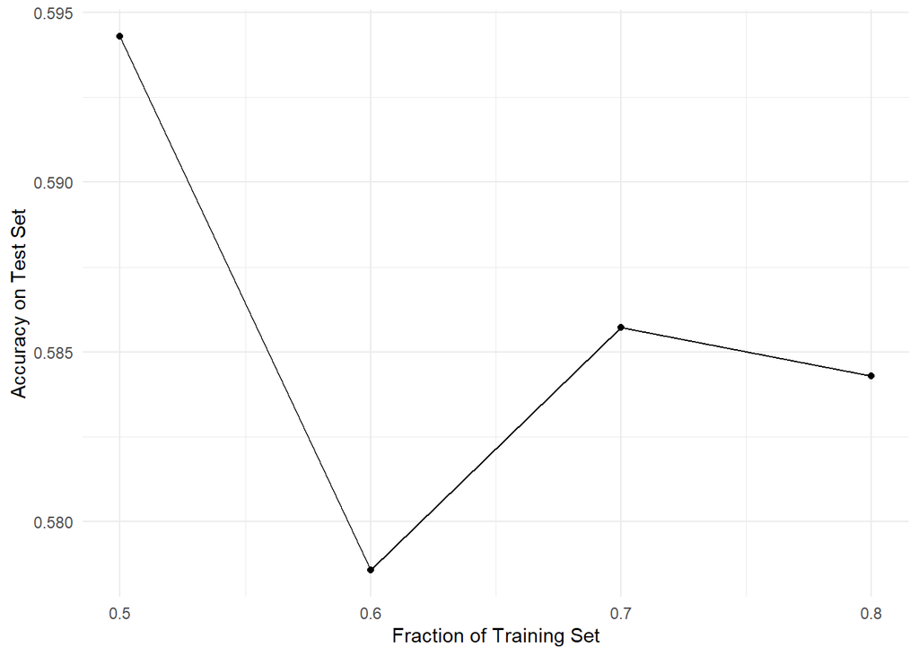

```r
# Test of the impact of the number of observations on results
fractions <- c(0.5, 0.6, 0.7, 0.8)
results_df <- data.frame(Fraction = numeric(0), Accuracy = numeric(0))

for (frac in fractions) {
  set.seed(123)
  sample_indices <- sample(1:nrow(data_train_k), size = floor(frac * nrow(data_train_k)))
  data_train_frac <- data_train_k[sample_indices, ]
  data_train_labels_frac <- data_train_frac$stroke

  knn_pred_frac <- knn(train = data_train_frac %>% select(-stroke),
                       test = data_test_k %>% select(-stroke),
                       cl = data_train_labels_frac, k = best_K)

  accuracy_frac <- sum(knn_pred_frac == data_test_labels) / length(data_test_labels)

  results_df <- rbind(results_df, data.frame(Fraction = frac, Accuracy = accuracy_frac))
}

# Plot
ggplot(data = results_df, aes(x = Fraction, y = Accuracy)) +
  geom_line() +
  geom_point() +
  labs(x = "Fraction of Training Set", y = "Accuracy on Test Set") +
  theme_minimal()
```

7. Can categorical variables be used in this method, and if so, how?

Yes, categorical variables can be used by encoding them into numerical values, for example, using dummy variables (one-hot encoding).

8. What are the advantages and disadvantages of this method?

Advantages of the KNN method:

It is easy to understand and implement. It does not make any assumptions about the distribution of the data used, which allows it to be applied to solving various problems. It can be used for both classification and regression problems. It is efficient because it works well with a large number of classes. The training phase is quick, mainly because this method does not construct a new model but uses available examples to make predictions when necessary. Disadvantages of the KNN method:

Difficulty in choosing the appropriate value of k. It does not work well with large datasets because the cost of calculating the distance between the new point and every existing point is significant, which decreases the efficiency of the algorithm. The algorithm does not support working with missing data. It is necessary to perform scaling (standardization and normalization) on the dataset before passing it to the KNN algorithm. Otherwise, variables with a larger range can dominate those with a smaller range, leading to incorrect predictions. It stores information about all cases in memory, which can lead to high memory usage, especially with large datasets. Task 3. KKNN Method

What distinguishes the KKNN method from the KNN method?

The KNN method uses Euclidean distance, whereas the KKNN method uses kernel functions to weight neighbors according to their distances, which allows it to handle data with more complex patterns. KKNN can be more computationally intensive than KNN.

Are there limitations regarding the choice of the value of k in this method?

In this method, there are also limitations regarding the choice of k. The higher the value of k, the less sensitive the model is to noise and outliers. However, this increases the risk that the model will not capture certain important data patterns. Conversely, a lower value of k allows for more complex decision boundaries that are better fitted to the data patterns, but outliers and noise have a greater influence.

Does the size of the dataset matter in this method? Check whether the number of observations affects the obtained results.

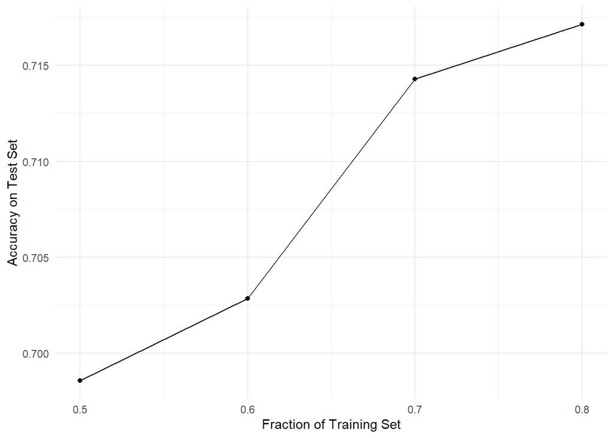

```r
# Test of the impact of the number of observations on results for KKNN
fractions <- c(0.5, 0.6, 0.7, 0.8)
results_kknn <- data.frame(Fraction = numeric(0), Accuracy = numeric(0))

set.seed(123)  # Move set.seed outside the loop to ensure reproducibility

for (frac in fractions) {
  # Resample until both classes are present
  repeat {
    sample_indices <- sample(1:nrow(data_train), size = floor(frac * nrow(data_train)))
    data_train_frac <- data_train[sample_indices, ]
    class_counts <- table(data_train_frac$stroke)

    # Check if both classes are present
    if (length(class_counts) == 2) {
      break
    }
    # If not, resample
  }

  # Build the KKNN model
  model_kknn_frac <- kknn(stroke ~ ., data_train_frac, data_test)

  # Extract predicted probabilities for class "1"
  predicted_probs_frac <- model_kknn_frac$prob[, "1"]

  # Check for NAs in predicted probabilities
  if (any(is.na(predicted_probs_frac))) {
    warning(paste("Predicted probabilities contain NA values for fraction", frac))
    accuracy_frac <- NA
  } else {
    predicted_class_frac <- ifelse(predicted_probs_frac >= 0.5, 1, 0)
    actual_class <- as.numeric(as.character(data_test$stroke))

    accuracy_frac <- sum(predicted_class_frac == actual_class) / length(actual_class)
  }

  results_kknn <- rbind(results_kknn, data.frame(Fraction = frac, Accuracy = accuracy_frac))
}

# Remove rows with NA Accuracy before plotting
results_kknn <- results_kknn[!is.na(results_kknn$Accuracy), ]

# Plot
ggplot(data = results_kknn, aes(x = Fraction, y = Accuracy)) +
  geom_line() +
  geom_point() +
  labs(x = "Fraction of Training Set", y = "Accuracy on Test Set") +
  theme_minimal()
```

Task 4. Logistic Regression

What are the assumptions of logistic regression?

In the logistic regression model, independent variables should not be collinear. The dependent variable should be appropriately coded because this model calculates the probability of the dependent variable taking the value 1. A randomly selected sample should also be sufficiently large.

How does this method handle categorical variables?

Logistic regression handles categorical variables by encoding them as dummy variables (binary variables). Each category is represented by a separate binary variable. It is important to avoid the dummy variable trap, which occurs when variables are linearly dependent.

Is data standardization necessary in logistic regression? Apply this method to data without standardization and with standardization. Compare the obtained results.

```r
model4_1 <- glm(data = data_train, family = binomial, formula = stroke ~ .)
summary(model4_1)
```

```
##
## Call:
## glm(formula = stroke ~ ., family = binomial, data = data_train)
##
## Coefficients:
##                              Estimate Std. Error z value Pr(>|z|)
## (Intercept)                 -3.209949   0.345846  -9.281  < 2e-16 ***
## genderMale                  -0.107342   0.095327  -1.126 0.260148
## age                          0.064015   0.003281  19.512  < 2e-16 ***
## hypertension1                0.576897   0.129098   4.469 7.87e-06 ***
## heart_disease1              -0.109192   0.153965  -0.709 0.478200
## ever_marriedYes             -0.109842   0.140662  -0.781 0.434868
## work_typeGovt_job           -1.405404   0.357088  -3.936 8.29e-05 ***
## work_typeNever_worked      -13.256748 258.545838  -0.051 0.959107
## work_typePrivate            -1.259621   0.340206  -3.703 0.000213 ***
## work_typeSelf-employed      -1.378885   0.359878  -3.832 0.000127 ***
## Residence_typeUrban          0.171125   0.092357   1.853 0.063902 .
## avg_glucose_level            0.003555   0.000826   4.304 1.68e-05 ***
## bmi                          0.017631   0.006781   2.600 0.009319 **
## smoking_statusnever smoked  -0.330338   0.122240  -2.702 0.006885 **
## smoking_statussmokes        -0.048773   0.149451  -0.326 0.744163
## smoking_statusUnknown       -0.493027   0.141116  -3.494 0.000476 ***
## ---
## Signif. codes:  0 '***' 0.001 '**' 0.01 '*' 0.05 '.' 0.1 ' ' 1
##
## (Dispersion parameter for binomial family taken to be 1)
##
##     Null deviance: 3876.0  on 2799  degrees of freedom
## Residual deviance: 2876.1  on 2784  degrees of freedom
## AIC: 2908.1
##
## Number of Fisher Scoring iterations: 13
```

```r
exp(coef(model4_1))
```

```
##                (Intercept)                 genderMale
##               4.035868e-02               8.982181e-01
##                        age              hypertension1
##               1.066108e+00               1.780505e+00
##             heart_disease1            ever_marriedYes
##               8.965582e-01               8.959760e-01
##          work_typeGovt_job      work_typeNever_worked
##               2.452680e-01               1.748507e-06
##           work_typePrivate     work_typeSelf-employed
##               2.837615e-01               2.518592e-01
##        Residence_typeUrban          avg_glucose_level
##               1.186639e+00               1.003561e+00
##                        bmi smoking_statusnever smoked
##               1.017788e+00               7.186810e-01
##       smoking_statussmokes      smoking_statusUnknown
##               9.523975e-01               6.107748e-01
```

```r
predicted_probs <- predict(model4_1, newdata = data_test, type = "response")
predicted_class <- ifelse(predicted_probs > 0.5, 1, 0)
actual_class <- as.numeric(as.character(data_test$stroke))

accuracy <- sum(predicted_class == actual_class) / length(actual_class)
cat("Accuracy without standardization:", accuracy, "\n")
```

```
## Accuracy without standardization: 0.7328571
```

```r
data_train_s <- data_train %>%
  mutate(age = scale(age),
         avg_glucose_level = scale(avg_glucose_level),
         bmi = scale(bmi))

data_test_s <- data_test %>%
  mutate(age = scale(age),
         avg_glucose_level = scale(avg_glucose_level),
         bmi = scale(bmi))

model4_2 <- glm(data = data_train_s, family = binomial, formula = stroke ~ .)
summary(model4_2)
```

```
##
## Call:
## glm(formula = stroke ~ ., family = binomial, data = data_train_s)
##
## Coefficients:
##                             Estimate Std. Error z value Pr(>|z|)
## (Intercept)                  1.21411    0.34298   3.540 0.000400 ***
## genderMale                  -0.10734    0.09533  -1.126 0.260148
## age                          1.49289    0.07651  19.512  < 2e-16 ***
## hypertension1                0.57690    0.12910   4.469 7.87e-06 ***
## heart_disease1              -0.10919    0.15397  -0.709 0.478200
## ever_marriedYes             -0.10984    0.14066  -0.781 0.434868
## work_typeGovt_job           -1.40540    0.35709  -3.936 8.29e-05 ***
## work_typeNever_worked      -13.25675  258.54584  -0.051 0.959107
## work_typePrivate            -1.25962    0.34021  -3.703 0.000213 ***
## work_typeSelf-employed      -1.37889    0.35988  -3.832 0.000127 ***
## Residence_typeUrban          0.17112    0.09236   1.853 0.063902 .
## avg_glucose_level            0.20616    0.04790   4.304 1.68e-05 ***
## bmi                          0.12887    0.04956   2.600 0.009319 **
## smoking_statusnever smoked  -0.33034    0.12224  -2.702 0.006885 **
## smoking_statussmokes        -0.04877    0.14945  -0.326 0.744163
## smoking_statusUnknown       -0.49303    0.14112  -3.494 0.000476 ***
## ---
## Signif. codes:  0 '***' 0.001 '**' 0.01 '*' 0.05 '.' 0.1 ' ' 1
##
## (Dispersion parameter for binomial family taken to be 1)
##
##     Null deviance: 3876.0  on 2799  degrees of freedom
## Residual deviance: 2876.1  on 2784  degrees of freedom
## AIC: 2908.1
##
## Number of Fisher Scoring iterations: 13
```

```r
exp(coef(model4_2))
```

```
##                (Intercept)                 genderMale
##               3.367293e+00               8.982181e-01
##                        age              hypertension1
##               4.449937e+00               1.780505e+00
##             heart_disease1            ever_marriedYes
##               8.965582e-01               8.959760e-01
##          work_typeGovt_job      work_typeNever_worked
##               2.452680e-01               1.748507e-06
##           work_typePrivate     work_typeSelf-employed
##               2.837615e-01               2.518592e-01
##        Residence_typeUrban          avg_glucose_level
##               1.186639e+00               1.228952e+00
##                        bmi smoking_statusnever smoked
##               1.137544e+00               7.186810e-01
##       smoking_statussmokes      smoking_statusUnknown
##               9.523975e-01               6.107748e-01
```

```r
predicted_probs_s <- predict(model4_2, newdata = data_test_s, type = "response")
predicted_class_s <- ifelse(predicted_probs_s > 0.5, 1, 0)
actual_class_s <- as.numeric(as.character(data_test_s$stroke))

accuracy_s <- sum(predicted_class_s == actual_class_s) / length(actual_class_s)
cat("Accuracy with standardization:", accuracy_s, "\n")
```

```
## Accuracy with standardization: 0.6028571
```

Do outliers affect the results obtained by this method? Verify this by building models based on different input data sets (with and without outliers).

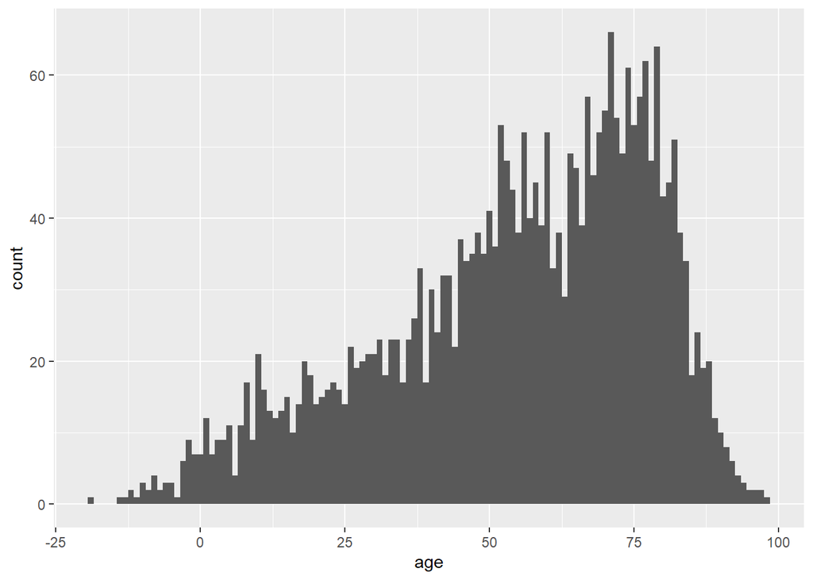

```r
# Histogram plots
ggplot(data_train, aes(x = age)) +
  geom_histogram(binwidth = 1)
```

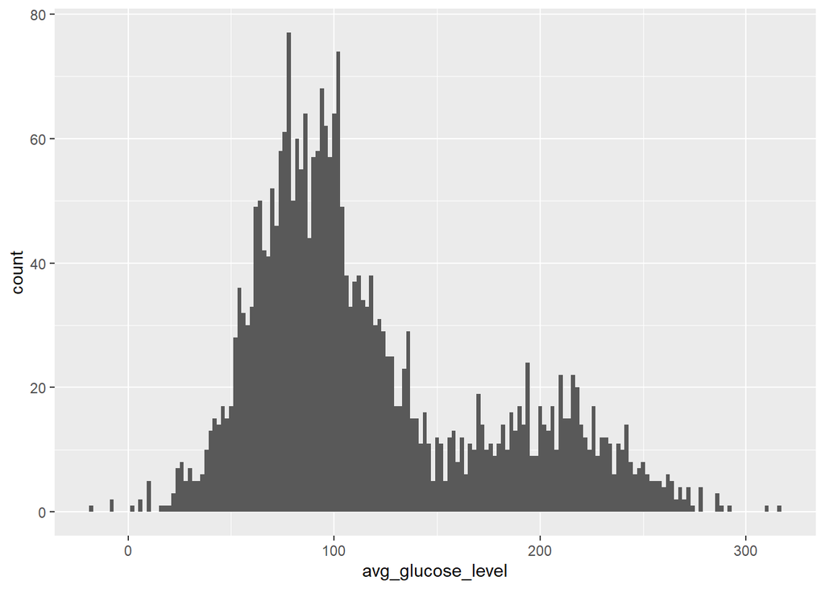

```r
ggplot(data_train, aes(x = avg_glucose_level)) +
  geom_histogram(binwidth = 2)
```

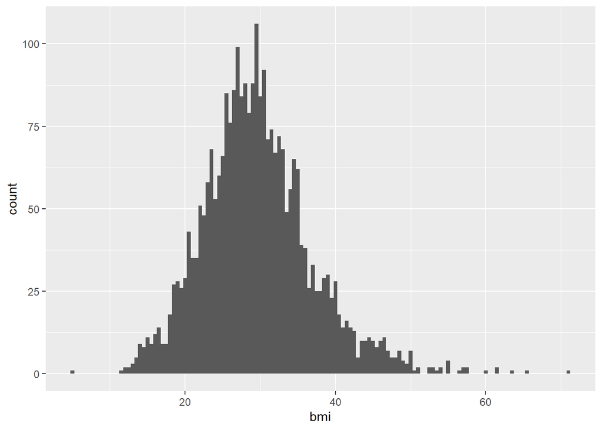

```r
ggplot(data_train, aes(x = bmi)) +
  geom_histogram(binwidth = 0.5)
```

```r
# Removing outliers
data_train_o <- data_train %>%
  filter(age <= quantile(age, 0.99),
         avg_glucose_level <= quantile(avg_glucose_level, 0.99),
         bmi <= quantile(bmi, 0.99))

model4_3 <- glm(data = data_train_o, family = binomial, formula = stroke ~ .)
summary(model4_3)
```

```
##
## Call:
## glm(formula = stroke ~ ., family = binomial, data = data_train_o)
##
## Coefficients:
##                              Estimate Std. Error z value Pr(>|z|)
## (Intercept)                -3.289e+00  3.571e-01  -9.210  < 2e-16 ***
## genderMale                 -6.958e-02  9.759e-02  -0.713 0.475828
## age                         6.692e-02  3.410e-03  19.627  < 2e-16 ***
## hypertension1               6.256e-01  1.333e-01   4.691 2.72e-06 ***
## heart_disease1             -1.103e-01  1.577e-01  -0.699 0.484492
## ever_marriedYes            -1.228e-01  1.434e-01  -0.856 0.391843
## work_typeGovt_job          -1.498e+00  3.617e-01  -4.143 3.43e-05 ***
## work_typeNever_worked      -1.328e+01  2.572e+02  -0.052 0.958819
## work_typePrivate           -1.378e+00  3.446e-01  -3.999 6.36e-05 ***
## work_typeSelf-employed     -1.483e+00  3.650e-01  -4.064 4.82e-05 ***
## Residence_typeUrban         2.079e-01  9.459e-02   2.198 0.027943 *
## avg_glucose_level           3.283e-03  8.702e-04   3.773 0.000162 ***
## bmi                         1.929e-02  7.537e-03   2.560 0.010478 *
## smoking_statusnever smoked -3.643e-01  1.256e-01  -2.900 0.003734 **
## smoking_statussmokes       -4.823e-02  1.523e-01  -0.317 0.751475
## smoking_statusUnknown      -4.875e-01  1.440e-01  -3.385 0.000713 ***
## ---
## Signif. codes:  0 '***' 0.001 '**' 0.01 '*' 0.05 '.' 0.1 ' ' 1
##
## (Dispersion parameter for binomial family taken to be 1)
##
##     Null deviance: 3758.8  on 2716  degrees of freedom
## Residual deviance: 2752.1  on 2701  degrees of freedom
## AIC: 2784.1
##
## Number of Fisher Scoring iterations: 13
```

```r
exp(coef(model4_3))
```

```
##                (Intercept)                 genderMale
##               3.727765e-02               9.327814e-01
##                        age              hypertension1
##               1.069207e+00               1.869307e+00
##             heart_disease1            ever_marriedYes
##               8.956070e-01               8.844269e-01
##          work_typeGovt_job      work_typeNever_worked
##               2.234670e-01               1.704794e-06
##           work_typePrivate     work_typeSelf-employed
##               2.521200e-01               2.269048e-01
##        Residence_typeUrban          avg_glucose_level
##               1.231101e+00               1.003288e+00
##                        bmi smoking_statusnever smoked
##               1.019481e+00               6.947123e-01
##       smoking_statussmokes      smoking_statusUnknown
##               9.529191e-01               6.141372e-01
```

```r
predicted_probs_o <- predict(model4_3, newdata = data_test, type = "response")
predicted_class_o <- ifelse(predicted_probs_o > 0.5, 1, 0)
actual_class_o <- as.numeric(as.character(data_test$stroke))

accuracy_o <- sum(predicted_class_o == actual_class_o) / length(actual_class_o)
cat("Accuracy after removing outliers:", accuracy_o, "\n")
```

```
## Accuracy after removing outliers: 0.7314286
```

Task 5. ROC Curve and AUC Value

What is a cutoff threshold?

A cutoff threshold is a value (level) that allows assigning an object to one of the classes based on the probability value.

What is an ROC curve and AUC value? How are they created/calculated?

The ROC curve evaluates the classifier’s performance, while the AUC (Area Under the Curve) value measures the area under the ROC curve, representing the overall classification ability of the model. The ROC curve is created by plotting the true positive rate against the false positive rate, and the AUC value is the integrated area under the ROC curve.

Present the ROC curve for the models: KNN and logistic regression. Compare them.

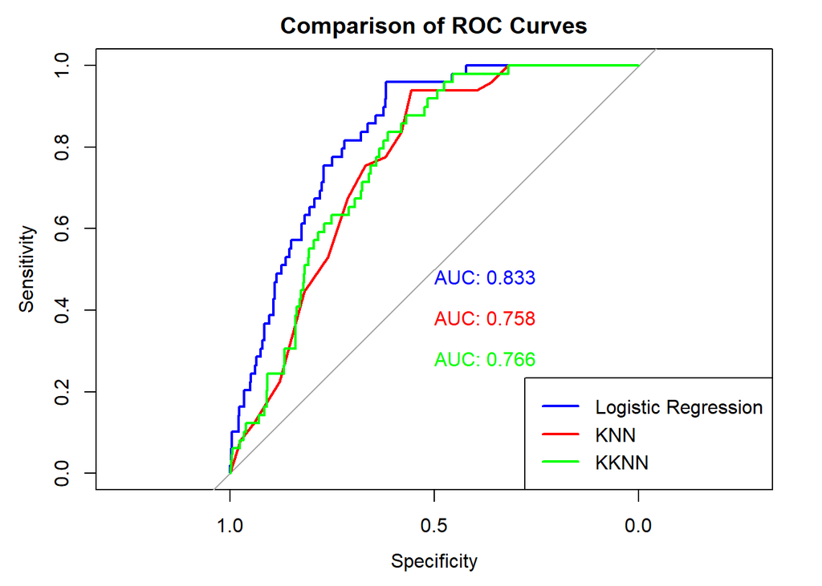

```r
# ROC curve for logistic regression
predicted_probs_lr <- predict(model4_1, newdata = data_test, type = "response")
roc_lr <- roc(data_test$stroke, predicted_probs_lr)
plot(roc_lr, col = "blue", print.auc = TRUE, main = "Comparison of ROC Curves")

# ROC curve for KNN
library(caret)
knn_model <- knn3(x = data_train_k %>% select(-stroke), y = data_train_labels, k = best_K)
predicted_probs_knn <- predict(knn_model, data_test_k %>% select(-stroke), type = "prob")
predicted_probs_knn_positive <- predicted_probs_knn[, "1"]
roc_knn <- roc(data_test$stroke, predicted_probs_knn_positive)
plot(roc_knn, col = "red", add = TRUE, print.auc = TRUE, print.auc.y = 0.4)

# ROC curve for KKNN
model_kknn <- kknn(stroke ~ ., data_train, data_test, k = best_K)

# Extract predicted probabilities for class "1"
predicted_probs_kknn <- model_kknn$prob[, "1"]

# Ensure that the response variable is numeric
actual_class_kknn <- as.numeric(as.character(data_test$stroke))

# Plot ROC curve
roc_kknn <- roc(actual_class_kknn, predicted_probs_kknn)
plot(roc_kknn, col = "green", add = TRUE, print.auc = TRUE, print.auc.y = 0.3)
legend("bottomright", legend = c("Logistic Regression", "KNN", "KKNN"),
       col = c("blue", "red", "green"), lwd = 2)
```